# 第03章 线性回归模型

## 3.1 一元线性回归

线性回归模型

- 利用`线性拟合`的方式探寻数据背后的规律
- 先通过搭建线性回归模型寻找散点`样本点`背后的趋势线
- 再利用回归曲线进行一些简答的预测分析或因果关系分析

### 3.1.1 一元线性回归的基本数学原理

一元线性回归模型(又称`简单线性回归模型`), 形式可表示为

- $$y = ax + b$$

  其中$y$为因变量, $x$为自变量, $a$为回归系数, $b$为截距

在机器学习中, 残差平方和又称为模型的`损失函数`(loss function)

- $$\sum(y^{(i)} - \hat{y}^{(i)})^2$$

  或

  $$\sum(y^{(i)} - (ax^{(i)} + b))^2$$

  其中 $y^{(i)}$ 为实际值, $\hat{y}^{(i)}$ 为与预测值

### 3.1.2 一元线性回归的代码实现

```python
import warnings

warnings.filterwarnings('ignore')
```

```python
from sklearn.linear_model import LinearRegression

regr = LinearRegression() #构造一个初始的线性回归模型并命名为regr

X = [[1], [2], [4], [5]]

Y = [2, 4, 6, 8]

regr.fit(X, Y) #用fit()函数完成模型搭建，此时的regr就是一个搭建好的线性回归模型

y = regr.predict([[1.5]])

print(y)

y = regr.predict([[1.5], [2.5], [4.5]])

print(y)
```

```
[2.9]
[2.9 4.3 7.1]
```

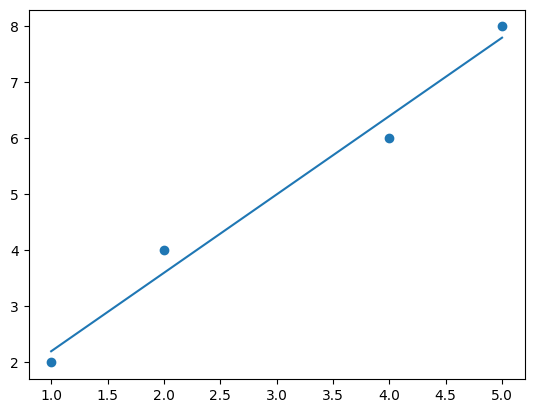

```
系数a：1.4000000000000004
截距b：0.7999999999999989
```

```python
import matplotlib.pyplot as plt

plt.scatter(X, Y)
plt.plot(X, regr.predict(X))
plt.show()

#通过coef_和intercept_属性可以得到此时趋势线的系数和截距

print('系数a：' + str(regr.coef_[0]))
print('截距b：' + str(regr.intercept_))
```

### 3.1.3 案例实战: 不同行业工龄与薪水的线性回归模型

```python
import pandas as pd
df = pd.read_excel('IT行业收入表.xlsx')
df.head()
```

|  | 工龄 | 薪水 |
| --- | --- | --- |
| 0 | 0.0 | 10808 |
| 1 | 0.1 | 13611 |
| 2 | 0.2 | 12306 |
| 3 | 0.3 | 12151 |
| 4 | 0.3 | 13057 |

```python
# 此时的工龄为自变量，薪水为因变量，通过如下代码进行自变量、因变量选取
X = df[['工龄']]
Y = df['薪水']
```

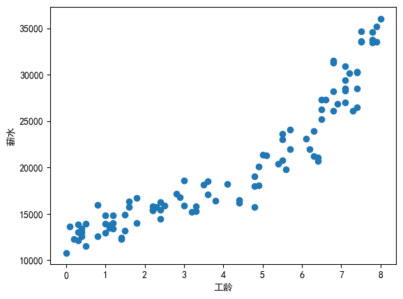

```python
# 通过如下代码可以将此时的散点图绘制出来：
from matplotlib import pyplot as plt
plt.rcParams['font.sans-serif'] = ['SimHei']  # 用来正常显示中文标签
plt.scatter(X,Y)
plt.xlabel('工龄')
plt.ylabel('薪水')
plt.show()
```

```python
from sklearn.linear_model import LinearRegression
regr = LinearRegression()  # 引入模型
regr.fit(X,Y)  # 训练模型
```

```
LinearRegression()
```

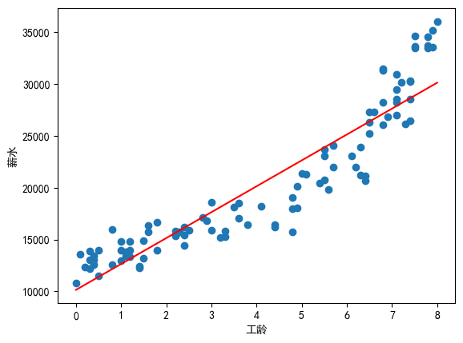

```python
plt.scatter(X,Y)
plt.plot(X, regr.predict(X), color='red')  # color='red'设置为红色
plt.xlabel('工龄')
plt.ylabel('薪水')
plt.show()
```

```python
print('系数a为:' + str(regr.coef_[0]))
print('截距b为:' + str(regr.intercept_))
```

```
系数a为:2497.1513476046866
截距b为:10143.131966873787
```

### 补充知识点: 模型优化

一元多次线性回归模型, 比如一元二次线性回归模型

- $$y = ax^2 + bx + c$$

```python
# 生成二次项数据：
from sklearn.preprocessing import PolynomialFeatures
poly_reg = PolynomialFeatures(degree=2)
X_ = poly_reg.fit_transform(X)
```

```python
print(X_[0:5])
```

```
[[1.   0.   0.  ]
 [1.   0.1  0.01]
 [1.   0.2  0.04]
 [1.   0.3  0.09]
 [1.   0.3  0.09]]
```

```python
# 模型训练
regr = LinearRegression()
regr.fit(X_, Y)
```

```
LinearRegression()
```

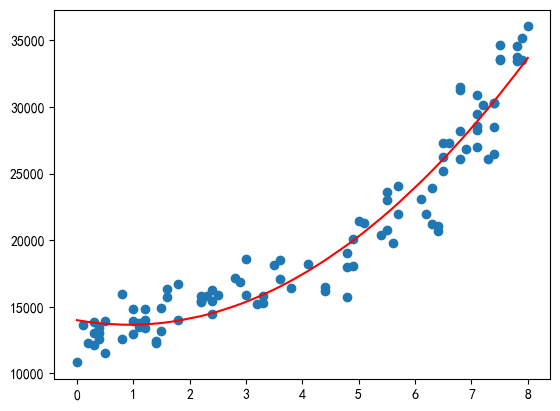

```python
# 可视化
plt.scatter(X,Y)
plt.plot(X, regr.predict(X_), color='red')
plt.show()
```

```python
# 打印系数和常数项
print(regr.coef_)  # 获取系数a, b
print(regr.intercept_)  # 获取常数项c
```

```
[   0.         -743.68080444  400.80398224]
13988.159332096886
```

## 3.2 线性回归模型评估

- 衡量线性拟合的优劣
  - R-squared
  - Adj.R-squared
- 衡量特征变量的显著性
  - P值

### 3.2.1 模型评估的编程实现

模型评估的数学原理比较复杂, 因此次数侧重于实战应用

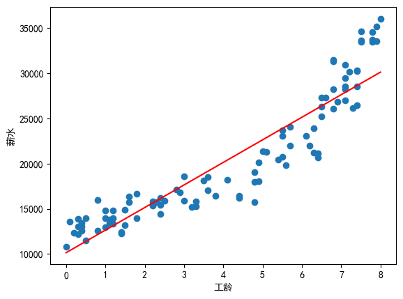

```
系数a为:2497.1513476046866
截距b为:10143.131966873787
```

```python
# 1.读取数据
import pandas
df = pandas.read_excel('IT行业收入表.xlsx')
X = df[['工龄']]
Y = df['薪水']

# 2.模型训练
from sklearn.linear_model import LinearRegression
regr = LinearRegression()
regr.fit(X,Y)

# 3.模型可视化
from matplotlib import pyplot as plt
plt.scatter(X,Y)
plt.plot(X, regr.predict(X), color='red')  # color='red'设置为红色
plt.xlabel('工龄')
plt.ylabel('薪水')
plt.show()

# 4.线性回归方程构造
print('系数a为:' + str(regr.coef_[0]))
print('截距b为:' + str(regr.intercept_))
```

```python
import statsmodels.api as sm
X2 = sm.add_constant(X)
est = sm.OLS(Y, X2).fit()
est.summary()  # 在非Jupyter Notebook的编辑器中需要写成print(est.summary())
```

OLS Regression Results

| Dep. Variable: | 薪水 | R-squared: | 0.855 |
| --- | --- | --- | --- |
| Model: | OLS | Adj. R-squared: | 0.854 |
| Method: | Least Squares | F-statistic: | 578.5 |
| Date: | Fri, 14 Mar 2025 | Prob (F-statistic): | 6.69e-43 |
| Time: | 19:56:30 | Log-Likelihood: | -930.83 |
| No. Observations: | 100 | AIC: | 1866. |
| Df Residuals: | 98 | BIC: | 1871. |
| Df Model: | 1 |  |  |
| Covariance Type: | nonrobust |  |  |

|  | coef | std err | t | P>\|t\| | [0.025 | 0.975] |
| --- | --- | --- | --- | --- | --- | --- |
| const | 1.014e+04 | 507.633 | 19.981 | 0.000 | 9135.751 | 1.12e+04 |
| 工龄 | 2497.1513 | 103.823 | 24.052 | 0.000 | 2291.118 | 2703.185 |

| Omnibus: | 0.287 | Durbin-Watson: | 0.555 |
| --- | --- | --- | --- |
| Prob(Omnibus): | 0.867 | Jarque-Bera (JB): | 0.463 |
| Skew: | 0.007 | Prob(JB): | 0.793 |
| Kurtosis: | 2.667 | Cond. No. | 9.49 |

Notes:  
[1] Standard Errors assume that the covariance matrix of the errors is correctly specified.

### 3.2.2 模型评估的数学原理

R-squared

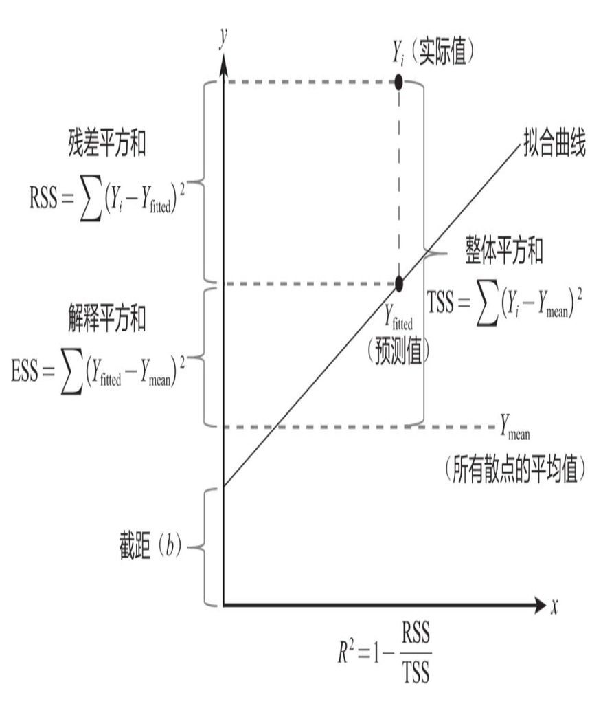

Adj.R-squared

$$R^2_{adj} = 1 - \frac{(1 - R^2)(n - 1)}{n - k - 1}$$

其中$n$为样本数量, $k$为特征变量数量, $k$越大, 对 $R^2_{adj}$ 的负影响越大, 不要为了追求高 $R^2$ 而添加过多的特征变量

## 3.3 多元线性回归

多元线性回归的原理和一元线性回归的原理在本质上是一样的

### 3.3.1 多元线性回归的数学原理和代码实现

最优化问题

$$ \underset{\overrightarrow{\beta}}{\min} (\overrightarrow{y} - X\overrightarrow{\beta})^T (\overrightarrow{y} - X\overrightarrow{\beta}) $$

其中 $\overrightarrow{y}$ 为长度为 $n$ (样本数) 的`列向量`, $\overrightarrow{\beta}$ 为长度为 $k$ (特征个数) 的`列向量`, $X$ 为 $n \times k$ 的特征矩阵

即

$$ \begin{aligned} \frac{ \partial (\overrightarrow{y} - X\overrightarrow{\beta})^T (\overrightarrow{y} - X\overrightarrow{\beta})}{\partial \overrightarrow{\beta}} &= 0 \\ \frac{\partial (\overrightarrow{y} - X\overrightarrow{\beta})}{\partial \overrightarrow{\beta}} \cdot \frac{ \partial (\overrightarrow{y} - X\overrightarrow{\beta})^T (\overrightarrow{y} - X\overrightarrow{\beta})}{\partial (\overrightarrow{y} - X\overrightarrow{\beta})} &= 0 \\ \frac{\partial (\overrightarrow{y} - X\overrightarrow{\beta})}{\partial \overrightarrow{\beta}} \cdot 2 (\overrightarrow{y} - X\overrightarrow{\beta})&= 0 \\ X^T(\overrightarrow{y} - X\overrightarrow{\beta}) &=0 \\ X^T\overrightarrow{y} - X^TX\overrightarrow{\beta} &=0 \\ X^TX\overrightarrow{\beta} &=X^T\overrightarrow{y} \\ \overrightarrow{\beta} &=(X^TX)^{-1}X^T\overrightarrow{y} \\ \end{aligned} $$

### 3.3.2 案例实战: 客户价值预测模型

```python
import pandas as pd
df = pd.read_excel('客户价值数据表.xlsx')
df.head()
```

|  | 客户价值 | 历史贷款金额 | 贷款次数 | 学历 | 月收入 | 性别 |
| --- | --- | --- | --- | --- | --- | --- |
| 0 | 1150 | 6488 | 2 | 2 | 9567 | 1 |
| 1 | 1157 | 5194 | 4 | 2 | 10767 | 0 |
| 2 | 1163 | 7066 | 3 | 2 | 9317 | 0 |
| 3 | 983 | 3550 | 3 | 2 | 10517 | 0 |
| 4 | 1205 | 7847 | 3 | 3 | 11267 | 1 |

```python
X = df[['历史贷款金额', '贷款次数', '学历', '月收入', '性别']]
Y = df['客户价值']
```

```python
from sklearn.linear_model import LinearRegression
regr = LinearRegression()
regr.fit(X,Y)
```

```
LinearRegression()
```

```python
print('各系数为:' + str(regr.coef_))
print('常数项系数k0为:' + str(regr.intercept_))
```

```
各系数为:[5.71421731e-02 9.61723492e+01 1.13452022e+02 5.61326459e-02
 1.97874093e+00]
常数项系数k0为:-208.42004079958383
```

其中这里通过regr.coef_获得是一个系数列表，分别对应不同特征变量前面的系数，也即k1、k2、k3、k4及k5，所以此时的多元线性回归曲线方程为：

$y = -208 + 0.057x_1 + 96x_2 + 113x_3 + 0.056x_4 + 1.97x_5$

```python
import statsmodels.api as sm  # 引入线性回归模型评估相关库
X2 = sm.add_constant(X)
est = sm.OLS(Y, X2).fit()
est.summary()
```

OLS Regression Results

| Dep. Variable: | 客户价值 | R-squared: | 0.571 |
| --- | --- | --- | --- |
| Model: | OLS | Adj. R-squared: | 0.553 |
| Method: | Least Squares | F-statistic: | 32.44 |
| Date: | Fri, 14 Mar 2025 | Prob (F-statistic): | 6.41e-21 |
| Time: | 19:56:30 | Log-Likelihood: | -843.50 |
| No. Observations: | 128 | AIC: | 1699. |
| Df Residuals: | 122 | BIC: | 1716. |
| Df Model: | 5 |  |  |
| Covariance Type: | nonrobust |  |  |

|  | coef | std err | t | P>\|t\| | [0.025 | 0.975] |
| --- | --- | --- | --- | --- | --- | --- |
| const | -208.4200 | 163.810 | -1.272 | 0.206 | -532.699 | 115.859 |
| 历史贷款金额 | 0.0571 | 0.010 | 5.945 | 0.000 | 0.038 | 0.076 |
| 贷款次数 | 96.1723 | 25.962 | 3.704 | 0.000 | 44.778 | 147.567 |
| 学历 | 113.4520 | 37.909 | 2.993 | 0.003 | 38.406 | 188.498 |
| 月收入 | 0.0561 | 0.019 | 2.941 | 0.004 | 0.018 | 0.094 |
| 性别 | 1.9787 | 32.286 | 0.061 | 0.951 | -61.934 | 65.891 |

| Omnibus: | 1.597 | Durbin-Watson: | 2.155 |
| --- | --- | --- | --- |
| Prob(Omnibus): | 0.450 | Jarque-Bera (JB): | 1.538 |
| Skew: | 0.264 | Prob(JB): | 0.464 |
| Kurtosis: | 2.900 | Cond. No. | 1.28e+05 |

Notes:  
[1] Standard Errors assume that the covariance matrix of the errors is correctly specified.  
[2] The condition number is large, 1.28e+05. This might indicate that there are  
strong multicollinearity or other numerical problems.